# RBP workflow

## Collapse redundant events

`find_se()` returns an exon once per transcript pair it is part of: an exon in two down transcripts and skipped by two up ones comes back four times. The event counts above already collapse these (`collapsed_events`). For the sequence analyses below we also keep one row per exon, so that an exon shared by many transcripts does not weigh more in the profiles and logos, and the background set is sized by exons rather than pairs. `n` records how many pairs each exon came from. The collapse is the same as in `collapse_redundant_events`, applied to the SE events, and like it collapses rows only for the same exon (gene, chromosome, start, end, strand) and the same event type.

```r
# TRUE: the sequence analyses below use one row per exon. FALSE: they use every
# SE event, one row per transcript pair, as before the collapse, to compare
collapse_se <- TRUE

se_collapsed <- se_events |>
    dplyr::mutate(exon_key = paste(gene_id, seqnames, start, end, strand, sep = ":")) |>
    dplyr::group_by(exon_key, event_type) |>
    plyranges::reduce_ranges_directed(
        n = plyranges::n(),
        gene_id = my_paste(gene_id),
        exon_id = my_paste(exon_id),
        tx_id = my_paste(tx_id),
        exon_rank = my_paste(exon_rank),
        event_tx_id = my_paste(event_tx_id),
  )

data.frame(
  set    = c("SE"),
  events = c(length(se_events)),
  exons  = c(length(se_collapsed)),
  max_n  = c(max(se_collapsed$n))
)
```

```
##   set events exons max_n
## 1  SE    306   228    12
```

```r
# the set the sequence analyses below use
se_exons <- if (collapse_se) se_collapsed else se_events
```

### SE exons per gene

How the SE events spread across genes: the number of distinct SE exons in each gene. `se_collapsed` already has one row per exon and gene, with `n` the events it came from, so the counts come straight from it.

```r
se_per_gene <- se_collapsed |>
  dplyr::group_by(gene_id) |>
  dplyr::summarise(n_events = sum(n),
                   n_exons  = plyranges::n())

data.frame(
  se_events = length(se_events),
  se_exons  = length(se_collapsed),
  se_genes  = nrow(se_per_gene)
)
```

```
##   se_events se_exons se_genes
## 1       306      228      190
```

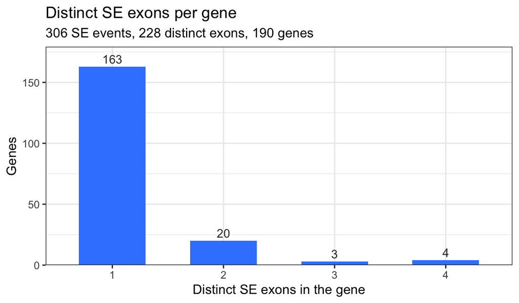

```r
# ggplot needs a data.frame, so the small per-gene summary is converted here
as.data.frame(se_per_gene) |>
  dplyr::count(n_exons) |>
  ggplot(aes(x = factor(n_exons), y = n)) +
  geom_col(fill = "#3A86FF", width = 0.6) +
  geom_text(aes(label = n), vjust = -0.4, size = 3.5, colour = "grey20") +
  scale_y_continuous(expand = expansion(mult = c(0, 0.1))) +
  labs(title = "Distinct SE exons per gene",
       subtitle = sprintf("%d SE events, %d distinct exons, %d genes",
                          length(se_events), length(se_collapsed),
                          nrow(se_per_gene)),
       x = "Distinct SE exons in the gene", y = "Genes") +
  theme_bw()
```

### GO enrichment of SE genes

Which biological processes are the genes with an SE event enriched for? The test set is every gene with at least one SE event; the background (universe) is every gene tested for DTU, since only those could give an event. Testing against the whole genome instead would mostly pick up which genes are expressed with several isoforms in this tissue. GO biological process terms, over-representation test with Benjamini-Hochberg adjustment, and `clusterProfiler::simplify()` to merge near-identical terms.

```r
se_genes  <- unique(sub("\\..*", "", as.character(se_events$gene_id)))
universe  <- unique(sub("\\..*", "", dtu_res$gene_id))
c(se_genes = length(se_genes), universe = length(universe))
```

```
## se_genes universe
##      190     4369
```

```r
go_se <- clusterProfiler::enrichGO(
  gene          = se_genes,
  universe      = universe,
  OrgDb         = org.Hs.eg.db::org.Hs.eg.db,
  keyType       = "ENSEMBL",
  ont           = "BP",
  pAdjustMethod = "BH",
  pvalueCutoff  = 0.05,
  qvalueCutoff  = 0.2,
  readable      = TRUE   # gene symbols in the geneID column
)
# merge redundant terms (semantic similarity > 0.7), keeping the most
# significant of each group
go_se <- clusterProfiler::simplify(go_se, cutoff = 0.7, by = "p.adjust",
                                   select_fun = min)
go_se_df <- as.data.frame(go_se)
nrow(go_se_df)
```

```
## [1] 19
```

```r
go_se_df |>
  dplyr::select(Description, GeneRatio, BgRatio, p.adjust, geneID) |>
  head(20)
```

```
##                                                               Description
## GO:1990778                         protein localization to cell periphery
## GO:0007155                                                  cell adhesion
## GO:0051668                                   localization within membrane
## GO:0007015                                    actin filament organization
## GO:0032880                             regulation of protein localization
## GO:0000902                                             cell morphogenesis
## GO:0060341                            regulation of cellular localization
## GO:0044319                              wound healing, spreading of cells
## GO:0016192                                     vesicle-mediated transport
## GO:0032231                   regulation of actin filament bundle assembly
## GO:1903077 negative regulation of protein localization to plasma membrane
## GO:0030155                                    regulation of cell adhesion
## GO:0030029                                   actin filament-based process
## GO:0042060                                                  wound healing
## GO:1903829                    positive regulation of protein localization
## GO:0015031                                              protein transport
## GO:0045184                          establishment of protein localization
## GO:0060627                       regulation of vesicle-mediated transport
## GO:0097435                              supramolecular fiber organization
##            GeneRatio  BgRatio    p.adjust
## GO:1990778    19/180 109/3941 0.000586719
## GO:0007155    36/180 354/3941 0.001611742
## GO:0051668    26/180 218/3941 0.001628784
## GO:0007015    19/180 132/3941 0.001998026
## GO:0032880    28/180 265/3941 0.004477878
## GO:0000902    23/180 206/3941 0.009157586
## GO:0060341    20/180 173/3941 0.014048941
## GO:0044319     6/180  19/3941 0.018529719
## GO:0016192    36/180 433/3941 0.019633980
## GO:0032231     8/180  37/3941 0.019633980
## GO:1903077     5/180  14/3941 0.022596137
## GO:0030155    21/180 203/3941 0.023934291
## GO:0030029    22/180 220/3941 0.024780247
## GO:0042060    14/180 111/3941 0.030248338
## GO:1903829    17/180 153/3941 0.032152667
## GO:0015031    34/180 421/3941 0.032152667
## GO:0045184    38/180 491/3941 0.032152667
## GO:0060627    15/180 129/3941 0.034644712
## GO:0097435    22/180 233/3941 0.037687262
```

[output cut: 20 more lines]

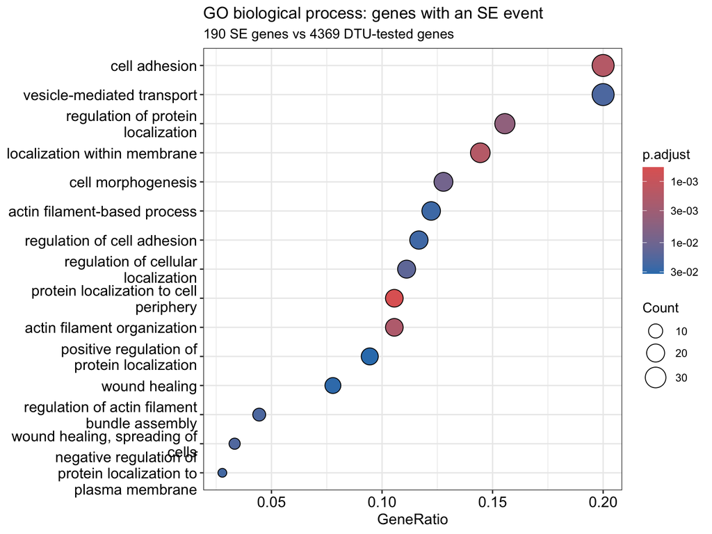

```r
if (nrow(go_se_df) > 0) {
  enrichplot::dotplot(go_se, showCategory = 15) +
    labs(title = "GO biological process: genes with an SE event",
         subtitle = sprintf("%d SE genes vs %d DTU-tested genes",
                            length(intersect(se_genes, universe)), length(universe)))
}
```

## Sequence context around the event exons, focusing on skipped exons (SE)

The analysis below uses a set of sequence-context helpers consolidated in `helper.R` (nucleotide-composition profiles, background exon sampling, splice-site logos and RBP motif scanning). The splicelogic package itself only exports `get_seq()` for sequence work, so these stay as paper-repo helpers (for now).

```r
source(here("workflows/helper.R"))
```

`slEventFlankProfiles()` takes a finder’s output straight away: it flanks each exon (strand-aware, so “upstream” is 5’ in transcription order), slides overlapping windows across the flank, and returns the per-window nucleotide fractions for each side.

```r
se_profiles <- slEventFlankProfiles(se_exons, genome = "hg38", width = 100)

# rows = exons, cols = window_nucleotide (e.g. w1_A)
dim(se_profiles$upstream)
```

```
## [1] 228  76
```

```r
dim(se_profiles$downstream)
```

```
## [1] 228  76
```

### Background set

We want to compare the sequence context of the events with that of a control set. For the control set (non-event exons), we sample as many exons as there are in `se_exons` (one per SE exon, or one per SE event with `collapse_se = FALSE`), drawn at random from the internal exons of transcripts with no evidence of differential usage (`pval > 0.5`).

```r
non_event <- slSampleNonEventExons(
  dtu_res, exons, n = se_exons, pval_min = 0.5, seed = 1
)
```

```r
non_event_profiles <- slEventFlankProfiles(
  non_event, genome = "hg38", width = 100
)
dim(non_event_profiles$upstream)
```

```
## [1] 228  76
```

The SE profiles stacked over the non-SE ones, on the same axes:

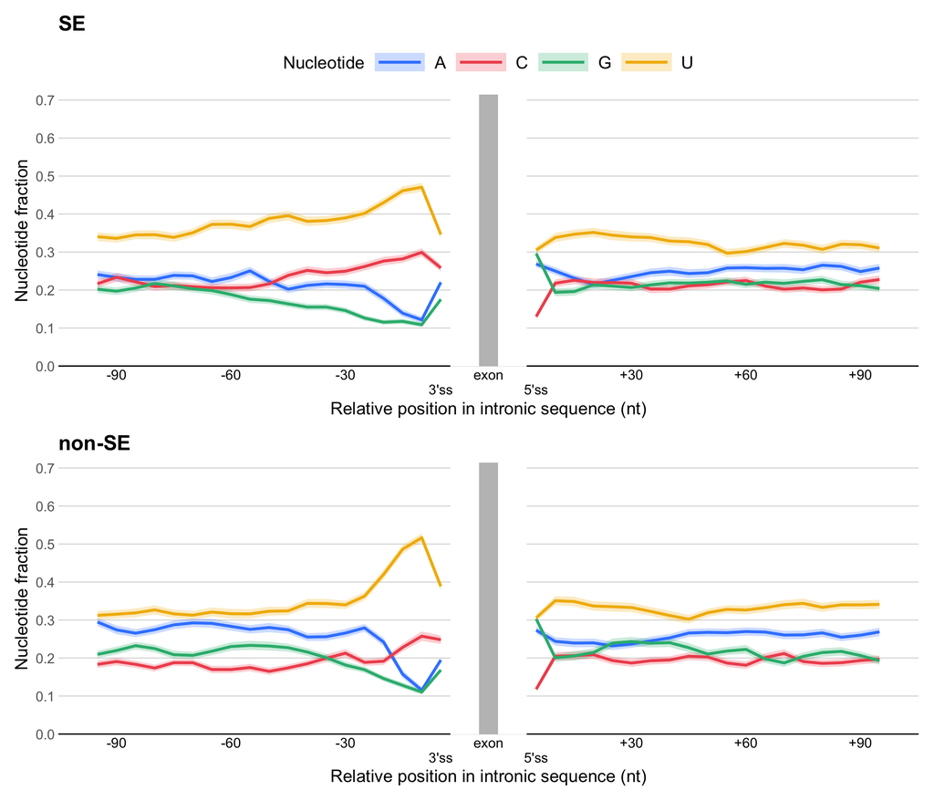

```r
p_se <- slPlotFlankProfiles(se_profiles, exon_label = "SE")

# one shared nucleotide legend at the top
patchwork::wrap_plots(
  p_se,
  slPlotFlankProfiles(non_event_profiles, exon_label = "non-SE"),
  ncol = 1, guides = "collect"
) & theme(legend.position = "top")
```

```r
# One text size for every poster figure, in pt at 300 dpi: tick labels, axis
# titles, legends and labels inside the plots all use it. se_composition and
# rna_map are drawn at 3.6 x 3 in and 600 dpi, half the size at twice the
# resolution, so they use poster_pt / 2 to come out the same size in pixels.
poster_pt <- 24
half_pt <- poster_pt / 2
same_text <- theme(text = element_text(size = half_pt),
                   axis.text = element_text(size = half_pt),
                   axis.title = element_text(size = half_pt),
                   legend.text = element_text(size = half_pt))

# the SE profile alone, for the poster, styled to sit side by side with the RNA
# map: the same size (3.6 x 3 in), text size, line width and legend layout.
# No plot or legend title (the poster panel's heading and caption carry them),
# but both axis titles are kept. Legend on the top, in one row.
p_se_poster <- slPlotFlankProfiles(se_profiles, exon_label = "SE",
                                   ylim = c(0, 0.5), hlines = seq(0, 0.4, by = 0.2),
                                   base_size = half_pt, linewidth = 0.8) +
  labs(title = NULL) +
  same_text +
  theme(legend.title = element_blank(),
        legend.position = "top",
        legend.direction = "horizontal",
        legend.key.width = grid::unit(0.5, "cm"),
        legend.key.height = grid::unit(7, "pt"),
        legend.box.spacing = grid::unit(2, "pt"),
        legend.margin = margin(0, 0, 0, 0),
        plot.margin = margin(2, 2, 2, 2))
dir.create(here("workflows", "figures", "poster"), showWarnings = FALSE, recursive = TRUE)
# a 3.6 x 3 in frame at 600 dpi
ggsave(here("workflows", "figures", "poster", "se_composition.png"), p_se_poster,
       width = 3.6, height = 3, dpi = 600)
```

The two sets, one panel per nucleotide (mean ± standard error), and below them the difference between them, SE minus non-SE:

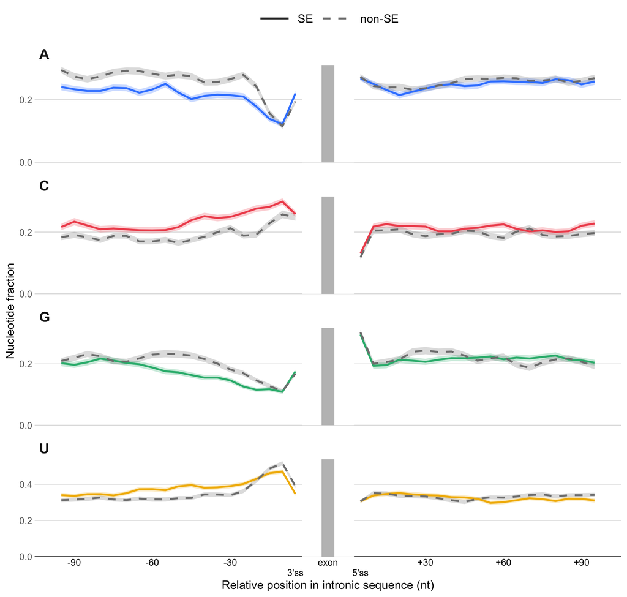

```r
se_vs_non_event <- list(SE = se_profiles, "non-SE" = non_event_profiles)

p_overlay <- slPlotFlankProfilesByNt(se_vs_non_event)
p_overlay
```

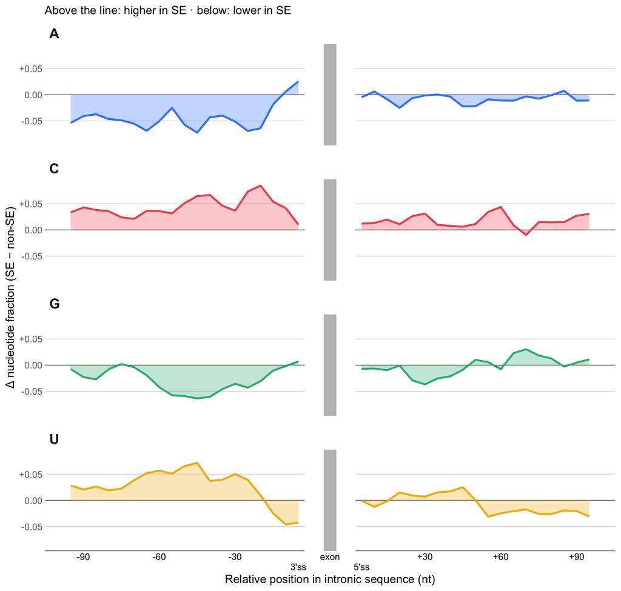

```r
slPlotFlankProfilesByNt(se_vs_non_event, difference = TRUE)
```

```r
# poster version: same width as the RNA map (3.6 in), stacked under
# se_composition
# Large text for the poster and no axis or legend titles (the poster caption
# carries them); the nucleotide as a label to the left of each row rather than
# a title above it, to leave the 4 short rows to the data.
p_overlay_poster <- slPlotFlankProfilesByNt(se_vs_non_event,
                                            base_size = 8, linewidth = 0.7) +
  facet_wrap(~ nt, ncol = 1, strip.position = "left", scales = "free_y") +
  theme(axis.title = element_blank(),
        legend.title = element_blank(),
        strip.placement = "outside",
        strip.text.y.left = element_text(angle = 0, face = "bold", size = 10),
        panel.spacing.y = grid::unit(0.15, "lines"),
        legend.key.width = grid::unit(0.8, "cm"),
        legend.box.spacing = grid::unit(2, "pt"),
        legend.margin = margin(0, 0, 0, 0),
        plot.margin = margin(2, 2, 2, 2))
# a 3.6 in frame at 600 dpi, text and lines halved as for se_composition
ggsave(here("workflows", "figures", "poster", "se_vs_background.png"), p_overlay_poster,
       width = 3.6, height = 2.325, dpi = 600)
```

An alternative, within-transcript control: for each event, the internal exon of the same transcript that is shared with the event partner and closest in rank to the event exon.

```r
matched <- slMatchedNonEventExons(se_events, exons)

slEventFlankProfiles(matched, genome = "hg38", width = 100) |>
  slPlotFlankProfiles(exon_label = "matched exon")
```

[output not shown]

## Splice-site sequence logos

The window profiles above average over 10 bp, which smooths the splice site away. `slFlankLogoMatrices()` keeps every base position separate and returns a position frequency matrix per side, running `width` bases into the intron and `exon_bases` into the exon so the boundary is inside the matrix.

Note which site each side carries: the region **upstream** of an exon is the end of the preceding intron and holds the **3’ splice site** (acceptor, `...ag | EXON`); the region **downstream** is the start of the following intron and holds the **5’ splice site** (donor, `EXON | gu...`).

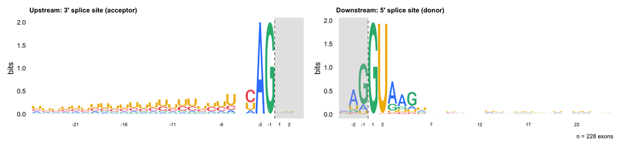

```r
se_logo <- slFlankLogoMatrices(se_exons, genome = "hg38",
                               width = 25, exon_bases = 3)

# letter height = information content, the classic logo scaling: unconstrained
# positions shrink to nothing and the consensus stands out
slPlotFlankLogo(se_logo, method = "bits")
```

The same for the background set, to see whether the event splice sites differ from those of exons in transcripts with no differential usage.

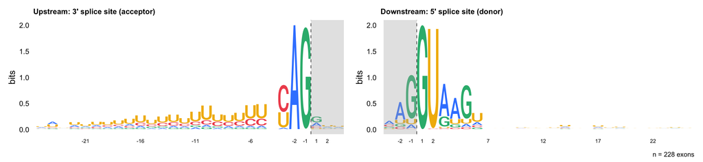

```r
non_event_logo <- slFlankLogoMatrices(non_event, genome = "hg38",
                                      width = 25, exon_bases = 3)

slPlotFlankLogo(non_event_logo, method = "bits")
```

```r
# where the two sets differ most, per position and nucleotide
delta <- se_logo$downstream - non_event_logo$downstream
round(delta[, order(-apply(abs(delta), 2, max))[1:6]], 3)
```

```
##        5     19      6     -3     13     25
## A  0.079 -0.075  0.009 -0.088  0.079 -0.044
## C  0.026  0.114  0.013  0.035 -0.013  0.075
## G -0.136  0.000  0.079  0.022 -0.070 -0.039
## U  0.031 -0.039 -0.101  0.031  0.004  0.009
```

## PTBP1 RNA map

Colours below are taken from the package, so they match `plot_transcripts()`: the up colour for transcripts with higher usage in WT (estimate > 0), the down colour for higher usage in KD, and `event_palette()` for event types.

```r
# the package's own colours, read from plot_transcripts() so they stay in sync
sl_up     <- formals(plot_transcripts)$up_color       # higher usage in WT
sl_down   <- formals(plot_transcripts)$down_color     # higher usage in KD
sl_grey   <- formals(plot_transcripts)$unknown_color  # not significant / other
sl_events <- event_palette()

# keep the standard chromosomes only, so every range is in the BSgenome
standard_chr <- function(gr) {
  gr <- GenomeInfoDb::keepStandardChromosomes(gr, pruning.mode = "coarse")
  GenomeInfoDb::seqlevels(gr) <- GenomeInfoDb::seqlevelsInUse(gr)
  gr
}

# the unfiltered counts: the per-sample usage plots use every transcript of a
# gene, not only those kept for DTU
se_raw   <- readRDS(here("workflows/data/GTEx_v9_ONT_SummarizedExperiment.rds"))
raw_gid  <- sub("\\..*", "", vapply(rowData(se_raw)$gene_id, `[`, character(1), 1))
raw_cond <- ifelse(se_raw$condition == "ctrl", "WT", "KD")
raw_cnt  <- assay(se_raw, "counts")
```

SE exons are on down transcripts (higher usage in KD) and skipped in up transcripts (higher in WT): with PTBP1 present the exon is skipped, so these are PTBP1-induced skipping events. From PTBP1’s RNA map we expect CU-rich motifs **upstream** of SE exons (around the 3’ splice site), relative to the background exons.

The motif is YCUY (Y = C or U), counted at every start position with overlapping matches allowed, in `W` nt of intron on each side of the exon. Each exon gives a 0/1 vector (1 where a motif starts), smoothed with a centred rolling mean; the profile is the mean ± s.e. across exons. The plot uses the same layout as the flank profiles above: one axis running through both introns, with the exon as a grey bar between them.

```r
W <- 200
smooth_nt <- 21
motif_regex <- "(?=[CU]CU[CU])"  # lookahead, so overlapping hits all count

# 0/1 matrix, exons x positions: 1 where a motif starts. get_seq() returns the
# sequence in transcription order (minus strand reverse-complemented), and the
# flanks are strand-aware, so column 1 of "upstream" is -W and column W is -1.
flank_matrix <- function(gr, side) {
  gr <- standard_chr(gr)
  fl <- if (side == "upstream") {
    plyranges::flank_upstream(gr, width = W)
  } else {
    plyranges::flank_downstream(gr, width = W)
  }
  seqs <- as.character(get_seq(fl, "hg38", as_rna = TRUE))
  m <- matrix(0L, nrow = length(seqs), ncol = W)
  for (i in seq_along(seqs)) {
    pos <- gregexpr(motif_regex, seqs[i], perl = TRUE)[[1]]
    pos <- pos[pos > 0]
    m[i, pos] <- 1L
  }
  m
}

sets <- list(SE = se_collapsed, background = non_event)
mats <- lapply(sets, function(gr) list(
  upstream   = flank_matrix(gr, "upstream"),
  downstream = flank_matrix(gr, "downstream")
))
sapply(mats, \(m) nrow(m$upstream))  # exons per set
```

```
##         SE background
##        228        228
```

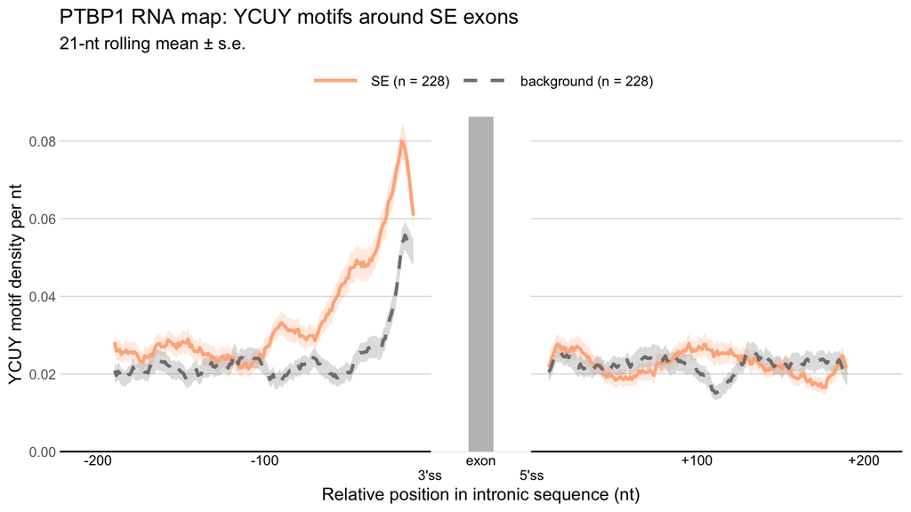

```r
# per-exon rolling mean over smooth_nt, then mean +/- s.e. across exons. As in
# slPlotFlankProfilesByNt(), both introns share one x axis: the upstream intron
# at x = 1..W (-W..-1 nt), then a gap holding the exon bar, then the
# downstream intron (+1..+W nt).
gap <- 60
profile_df <- function(m, side, set) {
  sm <- t(apply(m, 1, \(x) as.numeric(stats::filter(x, rep(1 / smooth_nt, smooth_nt), sides = 2))))
  pos <- if (side == "upstream") -W:-1 else 1:W
  tibble::tibble(
    set  = set,
    side = side,
    x    = if (side == "upstream") pos + W + 1 else pos + W + gap,
    mean = colMeans(sm, na.rm = TRUE),
    se   = apply(sm, 2, sd, na.rm = TRUE) / sqrt(nrow(sm))
  )
}

set_labels <- sprintf("%s (n = %d)", names(mats), sapply(mats, \(m) nrow(m$upstream)))
map_df <- dplyr::bind_rows(lapply(names(mats), function(s) dplyr::bind_rows(
  profile_df(mats[[s]]$upstream, "upstream", s),
  profile_df(mats[[s]]$downstream, "downstream", s)
))) |>
  dplyr::mutate(set = factor(set, levels = names(mats), labels = set_labels))

# x axis: nt from the exon every 100, the splice sites at the inner ends, and
# the exon bar in the middle (same labelling as .slFlankXAxis())
exon_x <- W + (gap + 1) / 2
bp <- seq(100, W, by = 100)
x_breaks <- c(rev(-bp) + W + 1, W, exon_x, W + gap + 1, bp + W + gap)
x_labels <- c(rev(-bp), "\n3'ss", "exon", "\n5'ss", paste0("+", bp))

# SE in its event_palette() colour, solid; background grey, dashed
map_cols <- setNames(c(sl_events[["se"]], "grey50"), set_labels)
map_lty  <- setNames(c("solid", "dashed"), set_labels)

ggplot(map_df, aes(x, mean, group = interaction(side, set))) +
  geom_ribbon(aes(ymin = mean - se, ymax = mean + se, fill = set),
              alpha = 0.25, colour = NA, na.rm = TRUE) +
  geom_line(aes(colour = set, linetype = set), linewidth = 1, na.rm = TRUE) +
  # the exon as a grey bar in the gap, and a black x-axis line under each
  # intron, broken at the exon
  .slFlankExonBar(W, gap, exon_x) +
  .slFlankXLine(W, gap) +
  coord_cartesian(clip = "off") +
  scale_colour_manual(values = map_cols) +
  scale_fill_manual(values = map_cols, guide = "none") +
  scale_linetype_manual(values = map_lty) +
  scale_x_continuous(breaks = x_breaks, labels = x_labels) +
  # from 0, with no padding below, so the x-axis line sits exactly on 0
  scale_y_continuous(limits = c(0, NA), expand = expansion(mult = c(0, 0.02))) +
  labs(title = "PTBP1 RNA map: YCUY motifs around SE exons",
       subtitle = sprintf("%d-nt rolling mean ± s.e.", smooth_nt),
       x = "Relative position in intronic sequence (nt)",
       y = "YCUY motif density per nt", colour = NULL, linetype = NULL) +
  .slFlankTheme() +
  theme(legend.key.width = grid::unit(1.2, "cm"))
```

Caveats: a 4-mer cannot start in the last 3 upstream positions without running into the exon, so those columns are always 0; the overlapping count gives long CU runs, such as the polypyrimidine tract, a lot of weight; and flanks of introns shorter than `W` run into the neighbouring exon.

## Example SE gene: SMAP1

Two panels: isoform usage per sample, and the events `find_all_events()` called in the gene. SMAP1 has two isoforms that differ by one 81-nt exon (plus their 5’ and 3’ ends). The exon-including isoform has higher usage in KD, so PTBP1 represses the exon. To plot another gene, add it to `example_genes`.

Usage is each transcript’s share of the gene’s counts in the unfiltered matrix. Each DTU transcript (FDR < 0.1, the ones the events come from) gets its own colour: shades of the up colour for higher usage in WT, shades of the down colour for higher in KD. Every other transcript of the gene is pooled as “other”.

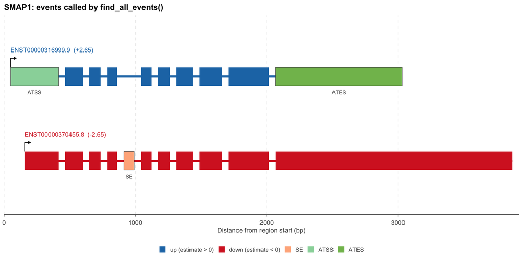

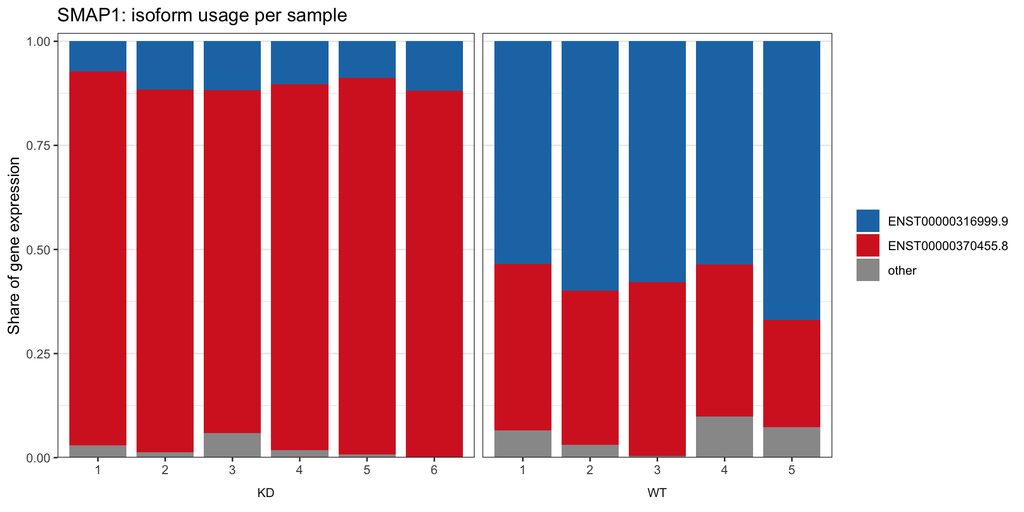

```r
example_genes <- c(SMAP1 = "ENSG00000112305")

# KD first, then WT, numbered within condition in donor order
ord <- order(factor(raw_cond, levels = c("KD", "WT")), se_raw$donor, colnames(se_raw))
samp_lab <- character(ncol(se_raw))
samp_lab[ord] <- ave(raw_cond[ord], raw_cond[ord], FUN = \(x) paste0(x, "-", seq_along(x)))

# the package colour, then two lighter shades of it, for genes with more than
# one DTU transcript in a direction
shades <- \(col) grDevices::colorRampPalette(c(col, "white"))(5)[1:3]
pal_up   <- shades(sl_up)
pal_down <- shades(sl_down)

plot_example_gene <- function(gene, gene_id) {
  ex_events <- events[sub("\\..*", "", events$gene_id) == gene_id]
  ex_exons  <- sig_exons[sub("\\..*", "", sig_exons$gene_id) == gene_id]

  # the DTU transcripts, WT-up first, each ordered by effect size
  ex_res <- dtu_res |>
    dplyr::filter(tx_name %in% unique(ex_exons$tx_id)) |>
    dplyr::arrange(dplyr::desc(estimates > 0), dplyr::desc(abs(estimates)))
  up_tx   <- ex_res$tx_name[ex_res$estimates > 0]
  down_tx <- ex_res$tx_name[ex_res$estimates < 0]

  # legend labels: the transcript id alone
  labs_tx <- setNames(ex_res$tx_name, ex_res$tx_name)

  gene_cnt <- raw_cnt[raw_gid == gene_id, , drop = FALSE]
  iso <- ifelse(rownames(gene_cnt) %in% names(labs_tx),
                labs_tx[rownames(gene_cnt)], "other")
  iso_levels <- c(labs_tx[up_tx], labs_tx[down_tx], "other")
  iso_cols <- setNames(c(pal_up[seq_along(up_tx)], pal_down[seq_along(down_tx)], sl_grey),
                       iso_levels)

  usage_df <- rowsum(gene_cnt, iso) |>
    sweep(2, colSums(gene_cnt), "/") |>
    as.data.frame() |>
    tibble::rownames_to_column("isoform") |>
    tidyr::pivot_longer(-isoform, names_to = "sample", values_to = "usage") |>
    dplyr::mutate(
      sample  = factor(samp_lab[match(sample, colnames(se_raw))], levels = samp_lab[ord]),
      isoform = factor(isoform, levels = iso_levels),
      # "KD-3" -> condition "KD" (one shared label under its samples), "3"
      condition = factor(sub("-.*", "", sample), levels = c("KD", "WT")),
      sample_n  = factor(as.integer(sub(".*-", "", sample)))
    )

  p_usage <- ggplot(usage_df, aes(sample_n, usage, fill = isoform)) +
    geom_col(width = 0.85) +
    # one panel per condition, its name once below its sample numbers
    facet_grid(~ condition, scales = "free_x", space = "free_x", switch = "x") +
    scale_fill_manual(values = iso_cols, drop = FALSE) +
    # zoom, not scale limits: a stack can sum to 1 + rounding error, and scale
    # limits would drop that top segment as out of range
    scale_y_continuous(expand = expansion(mult = c(0, 0.02))) +
    coord_cartesian(ylim = c(0, 1)) +
    labs(title = sprintf("%s: isoform usage per sample", gene),
         x = NULL, y = "Share of gene expression", fill = NULL) +
    theme_bw() +
    theme(strip.placement = "outside",
          strip.background = element_blank(),
          panel.grid.major.x = element_blank())

  # the events splicelogic called in this gene, on the transcripts they came
  # from
  p_events <- plot_transcripts(ex_events, ex_exons, rescale_introns = TRUE) +
    labs(title = sprintf("%s: events called by find_all_events()", gene))

  list(usage = p_usage, events = p_events)
}

example_plots <- Map(plot_example_gene, names(example_genes), example_genes)
for (p in example_plots) {
  print(p$events)
  print(p$usage)
}
```